# Using Polychrome With ggplot

Kevin R. Coombes

In this vignette, we describe how to use `Polychrome` palettes with the package `ggplot2`. The vignette will only run code if the `ggplot2` package is available.

```r
evalVignette <- requireNamespace("ggplot2", quietly = TRUE)
knitr::opts_chunk$set(eval = evalVignette)
```

## Getting Started

We want to build a custom palette of 40 colors for this application, with each block of four consecutive colors being distinguishable. We start by constructing a new palette in the usual way.

```r
library(Polychrome)
set.seed(935234)
P40 <- createPalette(40, c("#FF0000", "#00FF00", "#0000FF"), range = c(30, 80))
swatch(P40)
```

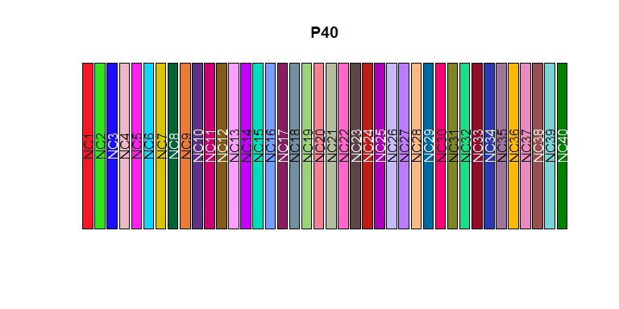

We achieve the goal of making the blocks of four colors being distinguishable by first sorting by hue, and then rearranging them into four-blocks.

```r
P40 <- sortByHue(P40)
P40 <- as.vector(t(matrix(P40, ncol=4)))
swatch(P40)
```

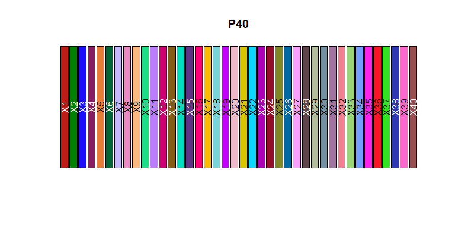

Here is the **key point** of this entire vignette: By default, `Polychrome` gives names to each of the colors in a palette. But, in `ggplot`, named colors will only be applied if they match the levels of an appropriate factor in the data. The simplest solution is to remove the names:

```r
names(P40) <- NULL
```

## Simulating Complex Data

For illustration purposes, we simulate a data set with a moderately complex structure. Specifically, we assume that we have

- Nine groups of samples,
- Four samples in each group,
- Three replicate experiments for each sample, and
- Measurements repeated over four days.

Here is the simulated design of the data set.

```r
## Nine groups
NG <- 9
gp <- paste("G", 1:NG, sep = "")
length(gp)
```

```
## [1] 9
```

```r
## Four Subjects per group
## 36 Subjects = 9 groups * 4 subjects/group
sid <- paste(rep(LETTERS[1:2], each=26), c(LETTERS, LETTERS), sep="")[1:(4*NG)]
length(sid)
```

```
## [1] 36
```

```r
## Three Reps per subject
## 108 Experiments
reps = factor(rep(c("R1", "R2", "R3"), times = length(sid)))
length(reps)
```

```
## [1] 108
```

```r
## Each experiment with measurements on four Days, so 432 data rows
daft <- data.frame(Day = rep(1:4, each=length(reps)),
                   Group = factor(rep(rep(gp, each=12), times = 4)),
                   Subject = factor(rep(rep(sid, each = 3), times=4)),
                   Rep = factor(rep(reps, times = 4)))
dim(daft)
```

```
## [1] 432   4
```

```r
summary(daft)
```

```
##       Day           Group        Subject    Rep
##  Min.   :1.00   G1     : 48   AA     : 12   R1:144
##  1st Qu.:1.75   G2     : 48   AB     : 12   R2:144
##  Median :2.50   G3     : 48   AC     : 12   R3:144
##  Mean   :2.50   G4     : 48   AD     : 12
##  3rd Qu.:3.25   G5     : 48   AE     : 12
##  Max.   :4.00   G6     : 48   AF     : 12
##                 (Other):144   (Other):360
```

Now we add simulated “measurements” taken on each replicate of each subject on each of four days.

```r
## Linear model with noise, ignoring group
beta <- runif(length(sid), 0.5, 2)
## "Measured" variable
attach(daft)
daft$variable <- rnorm(nrow(daft), 0, 0.2) + 1  + beta[as.numeric(Subject)]*Day
detach()
```

### Plotting the results.

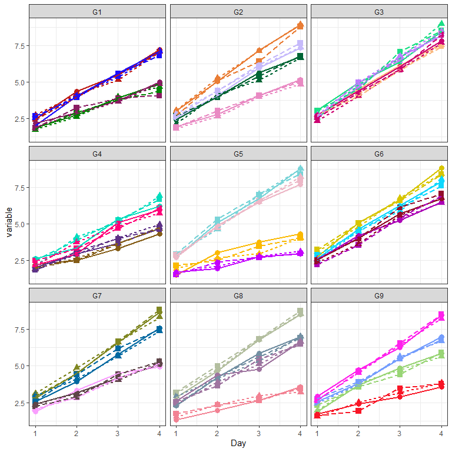

A faceted plot, colored by subject.

```r
library(ggplot2)
ggplot(daft, aes(x = Day, y = variable, colour = as.factor(Subject))) +
  geom_point(aes(shape = as.factor(Rep)), size = 3) +
  geom_line(aes(linetype = as.factor(Rep)), size = 0.8) +
  facet_wrap(. ~ Group, ncol = 3)+
  theme_bw() + theme(legend.position="none")+
  scale_color_manual(values = P40)
```